# act_report

## External Report

This report aims at providing the finding resulting from the exploration of data sets related to WeRateDogs twitter user. This exploration once several wrangling operations were completed.

**Finding 1**

Our first finding regarded the device used for tweeting. We found that the WeRateDogs account had more than 93% of its tweets made from an Iphone. Representing 2042 tweets on a total of 2175.

**Finding 2**

We then looked at the numerator distrition. We knew that WeRateDogs tend to have numerator above 10. We found that most of the dogs received a rating of 12. Ratings of 10 were the second most frequent rating given, followed by rating of 11.

The visualisation of the distribution of rating can be observed on the image below:

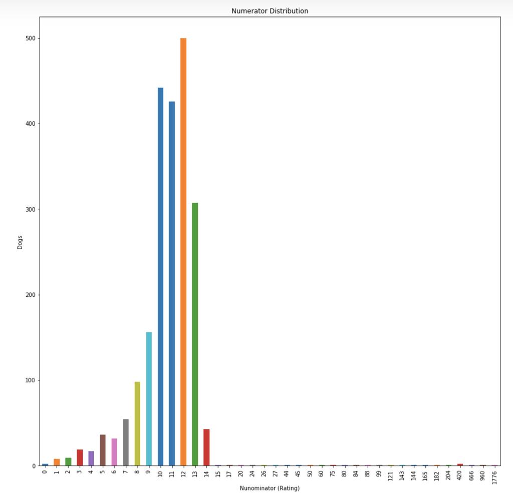

**Finding 3**

This operation was done to confirm what we were told, that most of the ratings were made on 10 (to make sure numerator were actually higher than denominators in many cases, as we were informed).

We found that more than 2000 tweets were showing ratings on 10. Which was far more common than any other denominator as we can observe below:

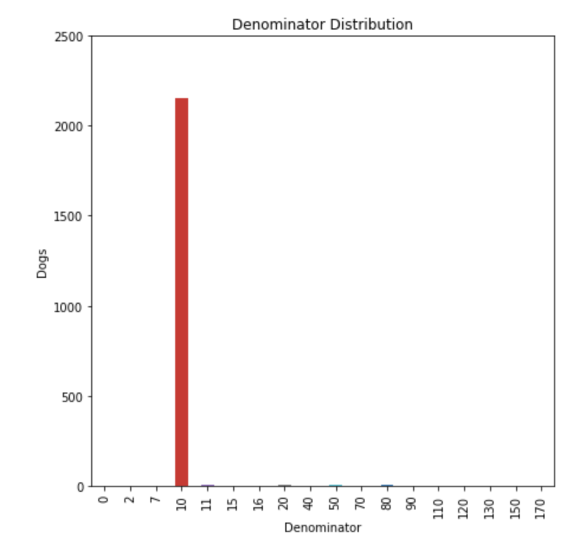

**Finding 4**

We analysed the most popular breed indicated by the software. Our analysis demonstrated that the most common type of breed were Golden retriever, with almost 140 matches, followed by Labrador retriever. The most common breeds recognized by the software can be observed below:

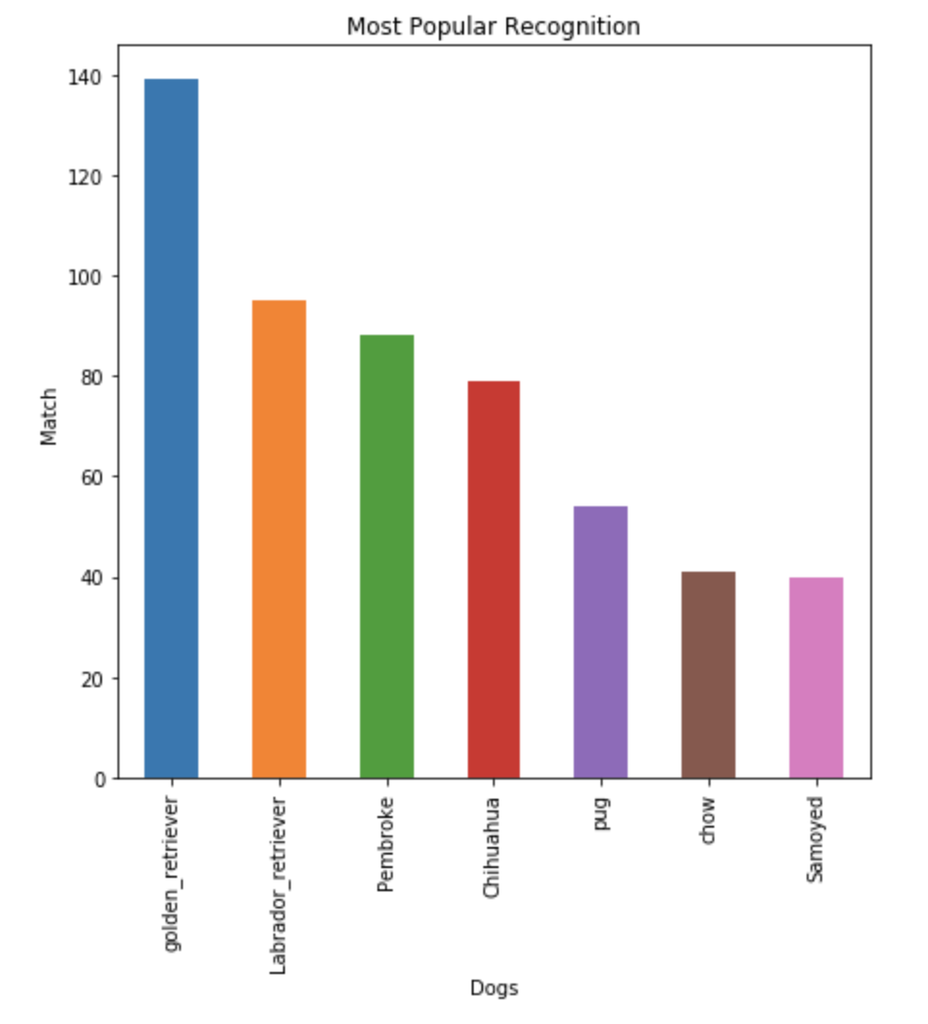

**Finding 5**

Finally, we looked at the repartition of dog stages within the tweets. Dogs stages regarded the different stage a dog is in, according to the explaination provided y #WeRateDogs book on Amazon

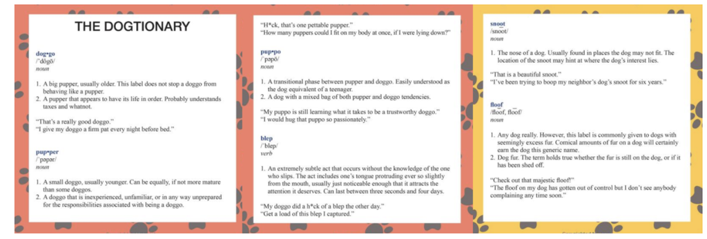

Our findings can be observed below:

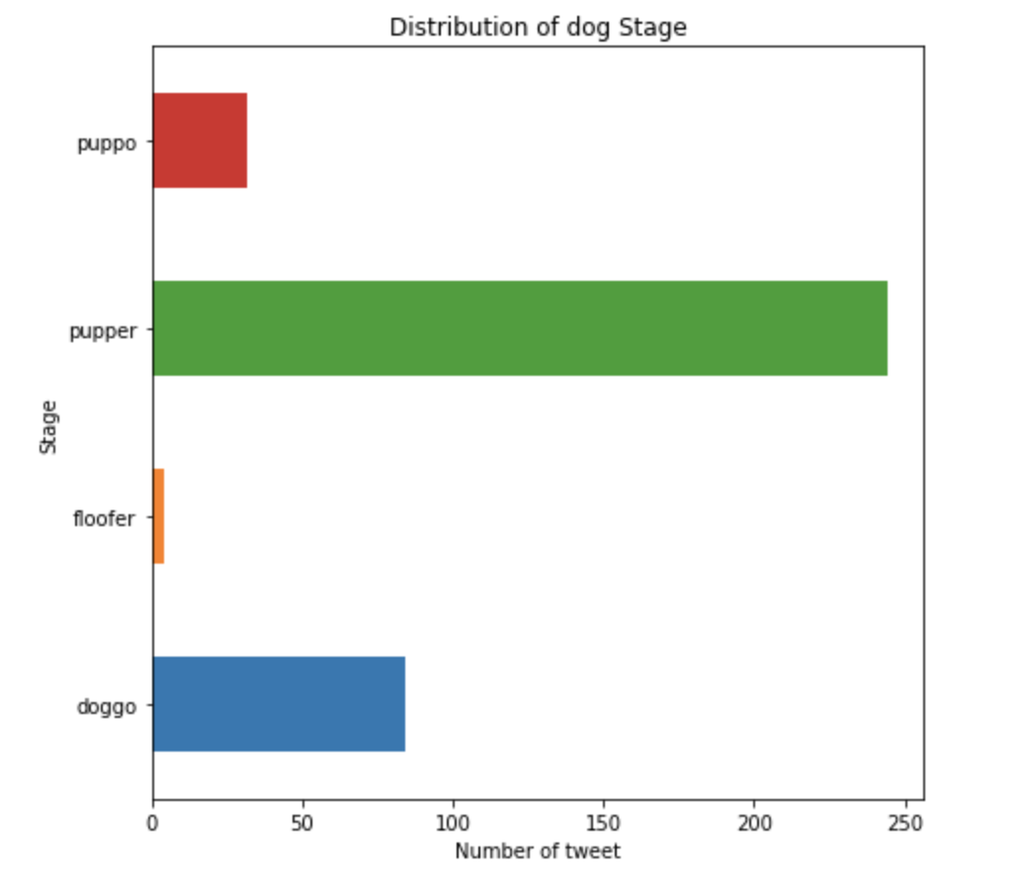

Pupper are the most common type of dog stage tweeted. Which is very likely due to their very cute appearance due to their young age.